# SLV Assignment 1

Group 4: Hidde, Ilya, Parisa, & Pim

2023-09-21

# Exploratory Data Analysis

### Part 1. Introduction

The dataset for the exploratory data analysis is downloaded from Kaggle (https://www.kaggle.com/datasets/mohidabdulrehman/ultimate-car-price-prediction-dataset) by Mohid Abdul Rehman. The data provides a comprehensive look at car listings available on a sales platform in Pakistan. Comprising of various companies, models, and other specifications the dataset serves as a rich source for understanding trends and patterns in the car market. The data contains 14 variables, each contributing a unique aspect to the information. The dataset can serve multiple analytical objectives. Whether the goal is to understand market trends, buyer preferences, or pricing strategies, the diverse set of attributes allows for a broad range of queries and visualizations.

This assignment is structured as follows: In the second part, we will tidy and summarize our data, making it possible to further process it. In part 3, we take a first look at some initial descriptive statistics and visualizations. This will give us an insight into interesting questions. In part 4, we provide graphs, which visualize our conclusions. Each part is accompanied with a discussion explaining what was done and how it helps to find answers for specified questions.

### Part 2. Data wrangling

#### Data Type

```r
data %>% head
```

```
##   X Company.Name Model.Name   Price Model.Year  Location Mileage Engine.Type
## 1 0       Toyota       Vitz 2385000       2017 Islamabad    9869      Petrol
## 2 1       Toyota    Corolla  111000       2019       KPK   11111      Petrol
## 3 2       Suzuki       Alto 1530000       2019       KPK   17500      Petrol
## 4 3       Suzuki       Alto 1650000       2019    Punjab    9600      Petrol
## 5 4       Toyota    Corolla 1435000       2010 Islamabad  120000      Petrol
## 6 5        Honda      Civic 3850000       2017    Punjab   22000      Petrol
##   Engine.Capacity  Color Assembly Body.Type Transmission.Type
## 1            1000 Silver Imported Hatchback         Automatic
## 2            1300  White    Local     Sedan         Automatic
## 3             660  White    Local Hatchback         Automatic
## 4             660  White    Local Hatchback            Manual
## 5            1300  Black    Local     Sedan            Manual
## 6            1500  Black    Local     Sedan         Automatic
##   Registration.Status
## 1       Un-Registered
## 2          Registered
## 3       Un-Registered
## 4          Registered
## 5          Registered
## 6          Registered
```

### Part 3. Descriptive statistics

We group the data by “Company.Name.”, then calculate various summary statistics for the “Price” column within each company, including the mean, median, minimum, maximum, and total count of cars. Then, we arrange the results in descending order of average price.

```r
result_average_price <- data %>%
  group_by(Company.Name) %>%
  summarise(
    Avg_Price = mean(Price, na.rm = TRUE),
    Median_Price = median(Price, na.rm = TRUE),
    Min_Price = min(Price, na.rm = TRUE),
    Max_Price = max(Price, na.rm = TRUE),
    Total_Cars = n()
  ) %>%
  arrange(desc(Avg_Price))

# Print the resulting summary
result_average_price
```

```
## # A tibble: 31 × 6
##    Company.Name Avg_Price Median_Price Min_Price Max_Price Total_Cars
##    <chr>            <dbl>        <dbl>     <int>     <int>      <int>
##  1 Porsche      18750000      15750000   5000000  45500000          8
##  2 Hummer       15000000      15000000  15000000  15000000          1
##  3 Range        14258788.      7300000   2400000  52500000         33
##  4 Jaguar       14000000      14000000  14000000  14000000          1
##  5 Lexus        13640864.      7000000   1800000  77500000         81
##  6 Audi          8582803.      8200000   1000000  17500000        208
##  7 BMW           5858343.      3050000   1150000  37500000        137
##  8 Mercedes      5253756.      3250000    635000  37000000        435
##  9 Jeep          4516667.      3500000   1200000  12500000          6
## 10 MINI          3570000       3200000   1800000   5500000          5
## # ℹ 21 more rows
```

#### Data Aggregation

Aggregate data to calculate summary statistics for multiple variables simultaneously: calculate the mean Mileage and Engine Capacity by Company Name.

```r
result_engine <- data %>%
  group_by(Company.Name) %>%
  summarise(
    Avg_Mileage = mean(Mileage),
    Avg_Engine_Capacity = mean(Engine.Capacity)
  ) %>%
  arrange(desc(Avg_Engine_Capacity))

print(result_engine)
```

```
## # A tibble: 31 × 3
##    Company.Name Avg_Mileage Avg_Engine_Capacity
##    <chr>              <dbl>               <dbl>
##  1 Hummer           140000                6200
##  2 Range             85722.               4014.
##  3 Jeep             110224.               3683.
##  4 Porsche           79125                3525
##  5 Lexus             82325.               3383.
##  6 SsangYong        124702.               2715.
##  7 Land             149946.               2660
##  8 BMW              106859.               2440.
##  9 Mercedes         105369.               2134.
## 10 Jaguar            50000                2000
## # ℹ 21 more rows
```

### Part 4. Exploratory plots

#### Frequency of car companies

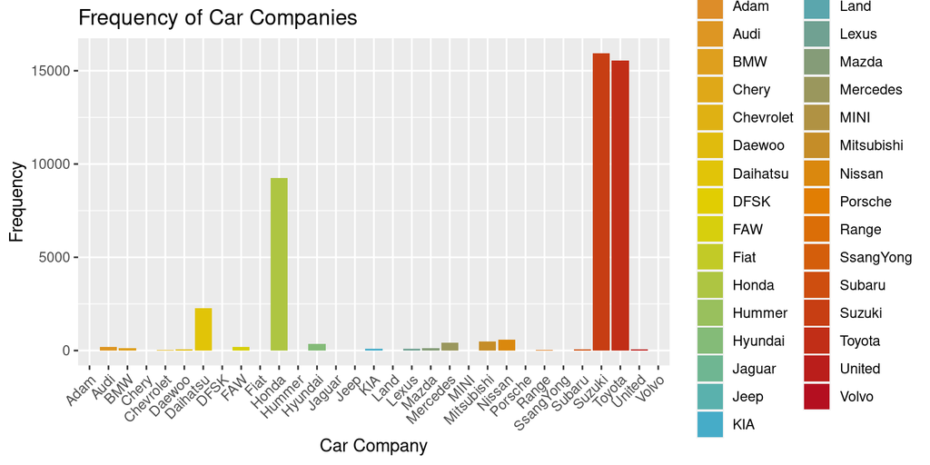

The plot shows that the market is heavily skewed in favor of Asian car producers, mostly related to Japan (Honda, Subaru, Suzuki, Toyota, Daihatsu), which makes total sense, taking market location into account. Car producers traditional for Europe and North America are barely presented on the market, mostly - in the upper segment, where the companies such as Mercedes can be seen.

#### Car prices as distribution

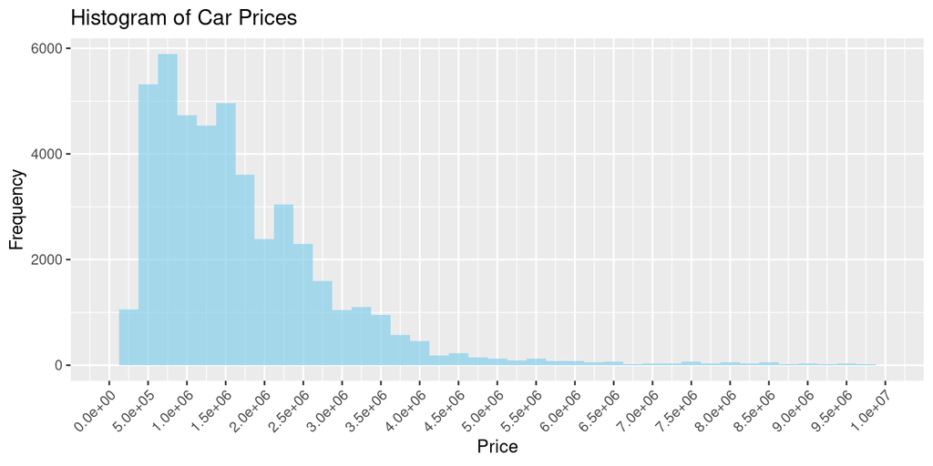

As it can be seen, Car pricing presents a normal distribution skewed to the right. Most of the cars can be seen in an average price segment, with cheap cars having almost similar price. For the upper segment of the market the citation is directly the opposite, such as the pricing can vary a lot.

#### Mileage and car price

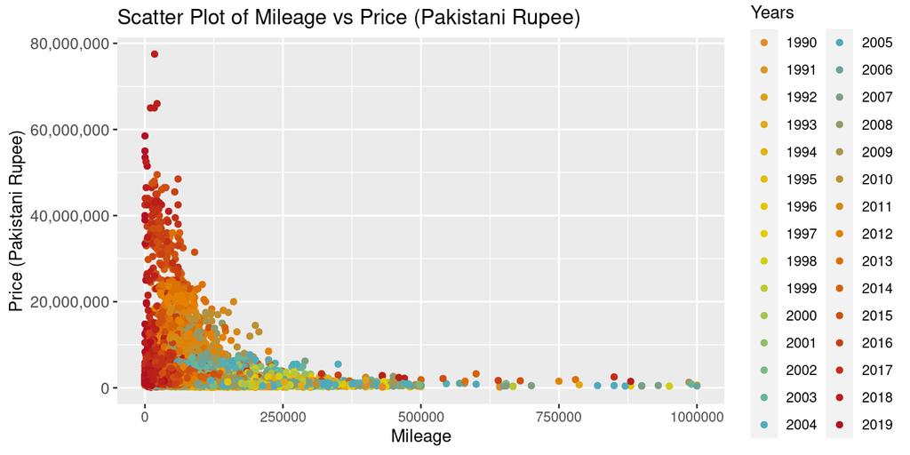

As it was expected, the relationship between average price, model year and mileage can be seen. Clearly, the smaller the mileage and the newer the model is, the higher the price. Interestingly, there are several cars presented in the dataframe with extremely high (>500000) mileage. It does not seem, however, that they can significantly affect outcomes in case data is used to run the model, since their prices are also really low.

#### Age and Price

##### Continuous

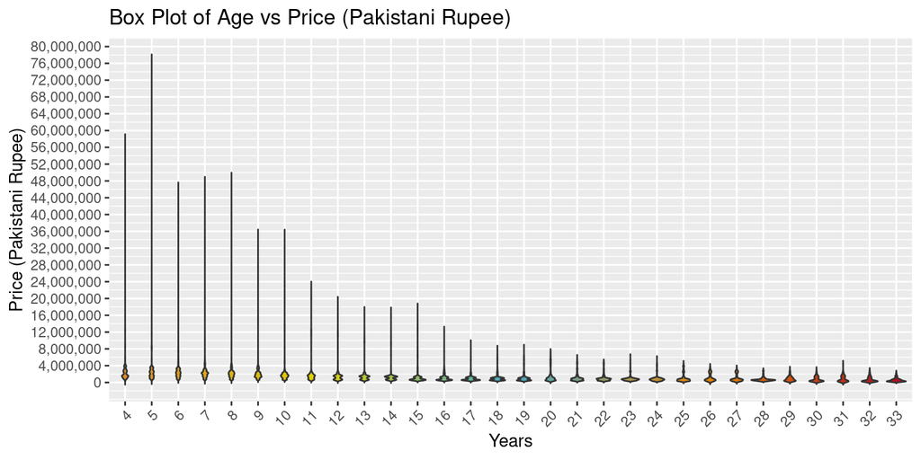

The violin boxplot confirms what was said before about the relationship between model year and the price. It is important to mention, however, that since the size of the dataframe is relatively large and pricing does not really tend to have a large variance, we can see a lot of outliers for each year. This can be seen in the long black tails.

##### As category

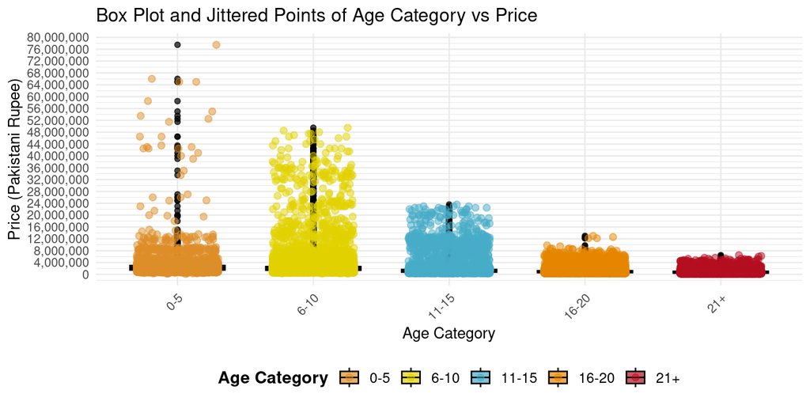

This plot show the age groups we created earlier, categorizing in relatively new cars and old/young timers. It is a more useful plot for interpreting the price ranges for consumers. It also the amount of oultiers in price, and a stabilization when the car gets older. Especially the young cars are traded in the high-end segment.

#### Top 3 companies and models

Since the market is heavily skewed in favor of Asian car producers, mostly related to Japan, we zoom into the three biggest companies and models there. For a fair comparison we only use the top 3 models of each company. This way we can more easily compare mileage and price and by creating a tidy plot for it.

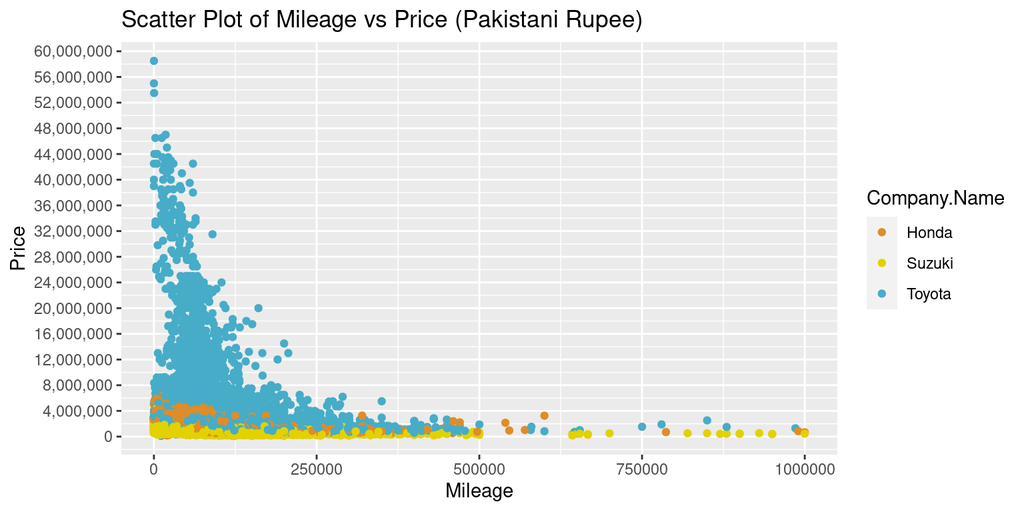

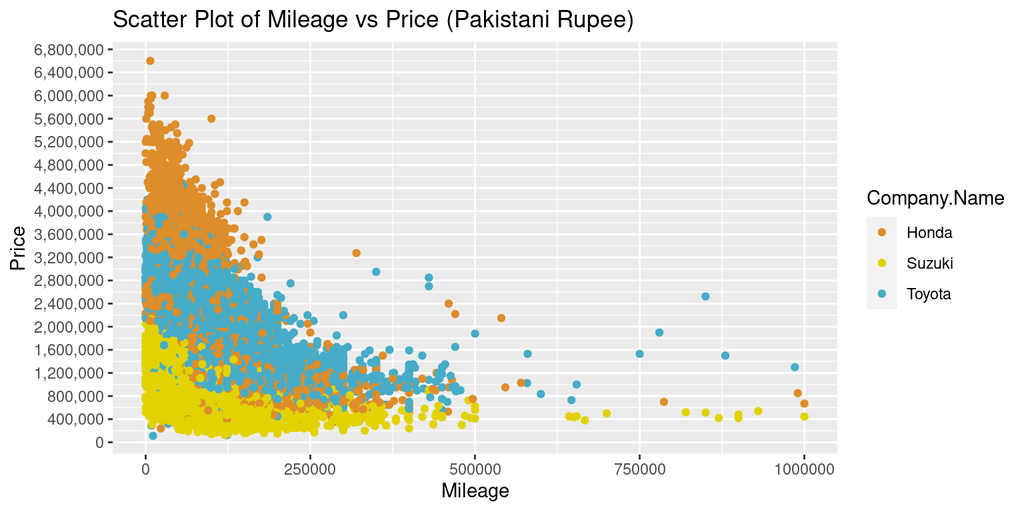

On these graphs, we can see 2 different scaling of the same graph for the Mileage vs Price for 3 models. As it can be seen, in a ascending order by the price, they can be placed as: Suzuki, Honda, Toyota. The second plot, using only top 3 models, is a lot more clear, which is useful for the final plot.

Finally, lets examine Mileage vs Price for the models which are the most popular ones: Honda, Suzuki, and Toyota.

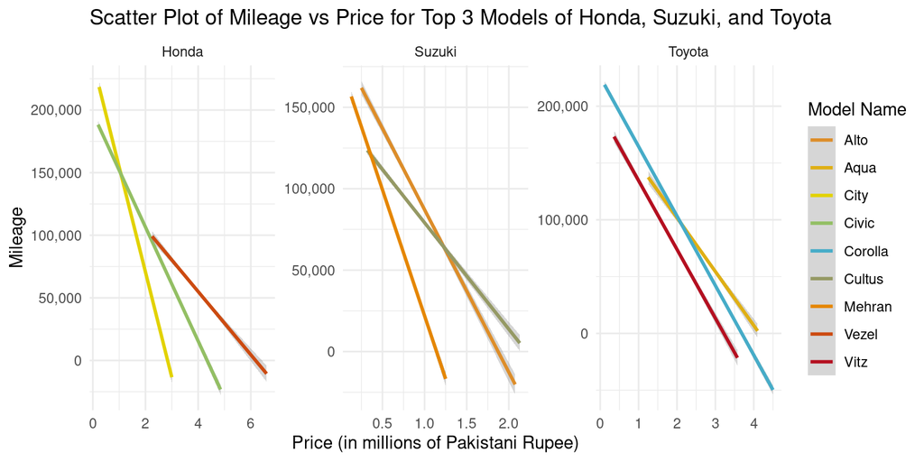

### Part 5. Explanation

Our Exploratory analysis showed the consistency of the dataframe and its relevance for those who can be interested in the car market analysis. Dataframe has no missing observations, but has quite a lot of outliers, mostly because of its size and a small variance across different grouping factors. We calculated descriptive statistics and built several exploratory plots, describing which information can be explored, using the data. The explanation for each of the graphs is provided below them. Overall, it can be concluded that the data is suitable for a more complex analytic approaches.